# Workshop Flanders - inundation time series

Sebastiaan Verbesselt

Instituut voor Natuur- en Bosonderzoek

Tytti Jussila

Finnish Environment Institute

2025-10-31

**Sebastiaan Verbesselt**  
Instituut voor Natuur- en Bosonderzoek  
https://orcid.org/0000-0003-0173-1123

**Tytti Jussila**  
Finnish Environment Institute  
https://orcid.org/0000-0003-4646-0152

# 1 Workshop Flanders - inundation pilot:

**Instructions**

We are going to evaluate the study areas after our field visit (15/10/2025). Please follow along with the presentation and code. I will discuss each step in the PowerPoint presentation, after which you will have time to analyse the code blocks. I will ask questions from time to time, and you will have the opportunity to test things out and engage in discussion.

## 1.1 Time series evaluation Webbekomsbroek

Before this workshop, we have already downloaded the datacube for the study area on OpenEO based on Hans’s script. The datacube and the other required data can be found here: “./source/hydrology/data/Retrieve_Datacube_Open_EO-Demervalley.Rmd”.

Please download the file together with the shapefile in the folder.

### 1.1.1 Step 1: Upload the required libraries/packages

```r
# Check automatically if you still need to install packages
list.of.packages <- c("tidyverse", "sf", "stars", "mapview", "lubridate", "dplyr", "rpart", "rpart.plot", "leaflet", "mapedit", "scales", "ggplot2", "rstudioapi","tidyr","zoo","np","kernlab","leafem","viridis","cubelyr","terra","signal","abind","INBOmd","INBOtheme")
new.packages <- list.of.packages[!(list.of.packages %in% installed.packages()[,"Package"])]
if(length(new.packages)) install.packages(new.packages)
# Load the packages
library(tidyverse)
library(sf)
library(stars)
library(mapview)
library(lubridate)
library(dplyr)
library(rpart)
library(rpart.plot)
library(leaflet)    # for interactive maps
library(leafem)
library(mapedit)    # for drawing polygons interactively
library(scales)
library(ggplot2)
library(rstudioapi)
library(tidyr)
library(zoo)
library(np)         # kernel regression
library(kernlab)    # Gaussian processes
library(viridis)
library(terra)
library(signal)
library(abind)
library(INBOmd)
library(INBOtheme)
```

### 1.1.2 Step 2: Load the datasets

Refer to the location of your data folder (interactively):

```r
if (requireNamespace("rstudioapi", quietly = TRUE)) {
  folder <- rstudioapi::selectDirectory(caption = "Select a folder")
  print(folder)
} else {
  message("rstudioapi not available; please install it with install.packages('rstudioapi').")
}
```

```r
if (is.null(folder)){
  folder <- "./source/hydrology/data/"
}
```

Load the data sets:

1. The area of interest (AOI):

```r
polygons <- st_read(paste0(folder,"raw/Webbekom_5testsites_demo.gpkg")) |> st_transform(32631) # Transform to local crs system (WGS 84 / UTM zone 31N - EPSG:32631)
```

```
## Multiple layers are present in data source G:\Gedeelde drives\Team_BioDiv\5_Projecten\2024_Biodiversa_habitatpilot\WP2_3\INBO_Github_Biodiversa_Habitat_Pilot\Habitat_condition_indicators\source\hydrology\data\raw\Webbekom_5testsites_demo.gpkg, reading layer `webbekom_testsites4'.
## Use `st_layers' to list all layer names and their type in a data source.
## Set the `layer' argument in `st_read' to read a particular layer.
```

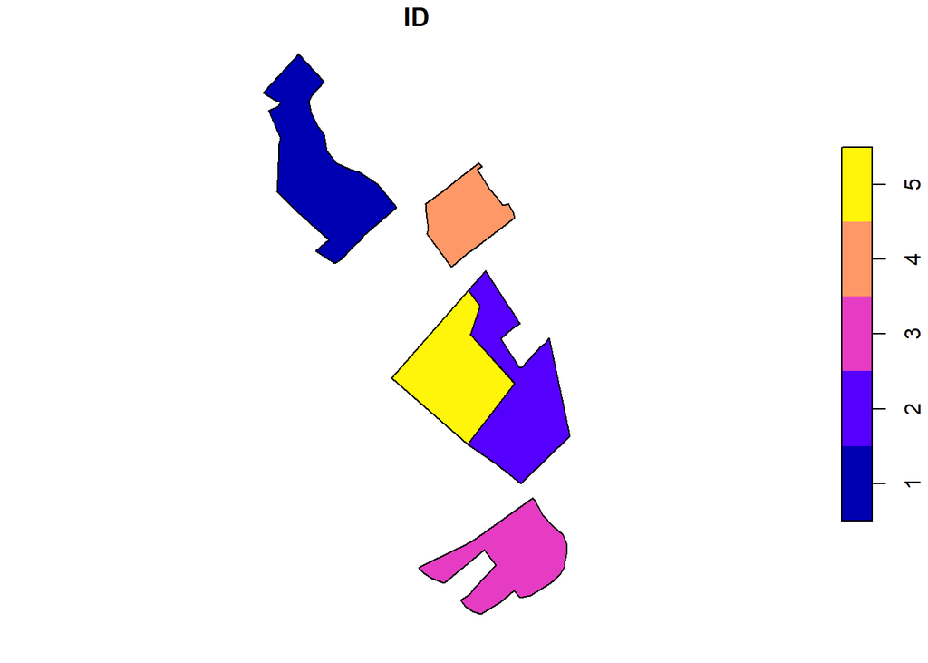

```r
polygons$ID <- c(1:5)
plot(polygons["ID"])
```

Select your area:

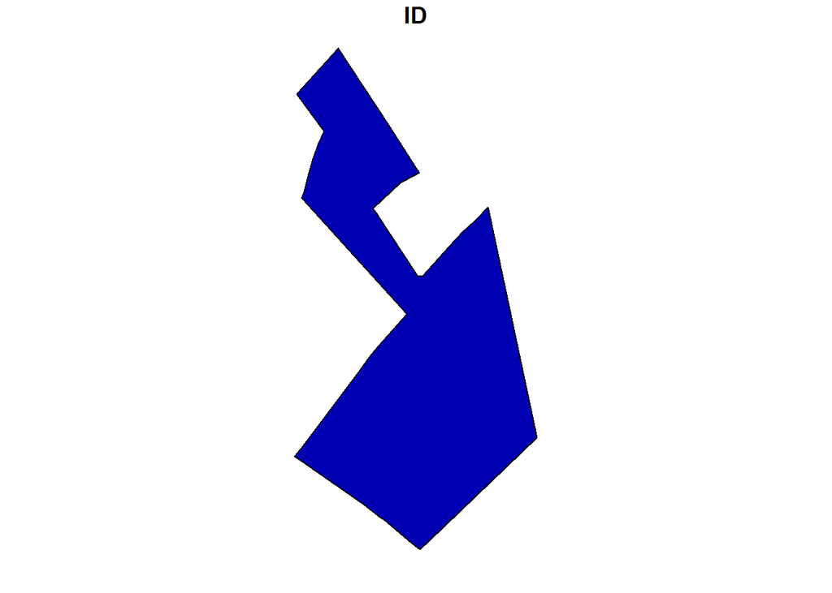

```r
AOI <- polygons %>% dplyr::filter(ID == 2)
plot(AOI["ID"])
```

2. Load the datacube:

```r
# First: proxy loading (fast)
obj <- read_stars(paste0(folder,"intermediate/polygon_Demervallei_3.nc"), proxy = TRUE) # Region code: 1: Kloosterbeemden, 2: Schulensmeer, 3: Webbekomsbroek
```

```
## B02, B03, B04, B05, B08, B8A, B11, B12, SCL,
```

```r
obj2 <- read_stars(paste0(folder,"intermediate/polygon_Demervallei_new_3.nc"), proxy = TRUE)
```

```
## B02, B03, B04, B05, B08, B8A, B11, B12, SCL,
```

```r
obj3 <- read_stars(paste0(folder,"intermediate/polygon_Demervallei_last_3.nc"), proxy = TRUE)
```

```
## B02, B03, B04, B05, B08, B8A, B11, B12, SCL,
```

```r
# Ensure both have the same dimension names
# names(st_dimensions(obj))
# names(st_dimensions(obj2))
# names(st_dimensions(obj3))

# Drop any extra dimension (e.g., a band dimension named "X" or similar)
obj  <- adrop(obj)
obj2 <- adrop(obj2)
obj3 <- adrop(obj3)

# Now combine along time
combined <- c(obj, obj2, along = "t")
combined <- c(combined, obj3, along = "t")
# st_dimensions(obj)
# st_dimensions(obj2)
# st_dimensions(obj3)
st_dimensions(combined)
```

```
##   from  to  offset delta                refsys                    values x/y
## x    1 450  644240    10 WGS 84 / UTM zone 31N                      NULL [x]
## y    1 293 5650760   -10 WGS 84 / UTM zone 31N                      NULL [y]
## t    1 858      NA    NA               POSIXct 2020-01-01,...,2025-10-13
```

Remove the data layers that we wont use in the workshop to make sure we have enough free memory.

```r
obj <- combined # Assign the combined datacube to the obj datacube (make a copy)
rm(obj2, obj3, combined) # Remove obj2, combined.

# Load now the data in memory:
obj <- st_as_stars(obj, along = "t")
```

3. Load the WMS links for the ortho images of Flanders:

```r
wms_ortho_most_recent <- "https://geo.api.vlaanderen.be/OMWRGBMRVL/wms" # Most recent ortho image, winter, medium scale resolution.
wms_ortho <- "https://geo.api.vlaanderen.be/OMW/wms" # historical ortho images, winter, medium scale resolution.
wms_DEM <- "https://geo.api.vlaanderen.be/DHMV/wms" # Digital elevation model
```

4. Load Tytti’s model:

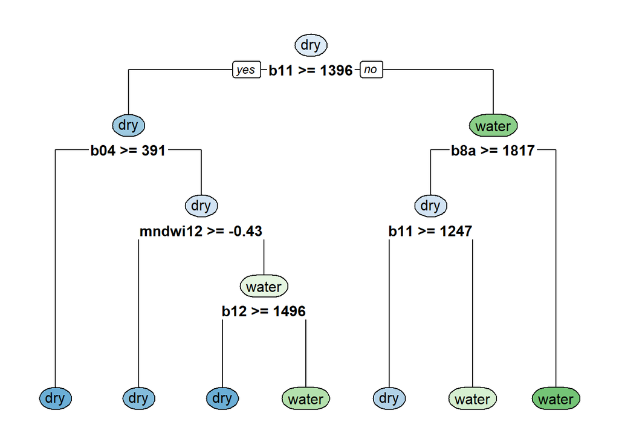

```r
# Load the decision tree model
load(paste0(folder,"raw/jussila_decisiontree.RData"))

# Visualize the decision tree structure
rpart.plot(tree_jussila, tweak = 1, extra = 0)
```

5. The GPS points (select immediately the points that fall within the selected polygon):

```r
# Load the points
points <- st_read(paste0(folder,"raw/survey_points_HabitatPilot.gpkg"))
# Change multipoint to single point (if necessary)
points_single <- st_cast(points, "POINT")
points_single
```

|  | point_id | label | date | photo | geom |
| --- | --- | --- | --- | --- | --- |
| 1 | P1 | Inundated open | 2025-10-15 12:14:22.707000 | video/survey-points_20251015101435249.jpg |  |
| 2 | P2 | Non-inundated | 2025-10-15 12:27:57.205001 | video/survey-points_20251015102834437.jpg |  |
| 3 | P3 | Non-inundated | 2025-10-15 12:35:00.803999 | video/survey-points_20251015103622230.jpg |  |
| 4 | P4 | Inundated open | 2025-10-15 12:37:51.499000 | video/survey-points_20251015103811921.jpg |  |
| 5 | P5 | Inundated close | 2025-10-15 13:02:08.831999 | NA |  |
| 6 | P6 | Inundated close | 2025-10-15 13:03:13.654000 | video/survey-points_20251015110342279.jpg |  |
| 7 | P7 | Inundatied semi | 2025-10-15 13:05:39.451999 | video/survey-points_20251015110551834.jpg |  |
| 8 | P8 | Inundated open | 2025-10-15 13:11:49.611000 | video/survey-points_20251015111156481.jpg |  |
| 9 | P9 | Inundated open | 2025-10-15 13:37:16.275999 | video/survey-points_20251015113733093.jpg |  |

```r
# Select points that overlap with
points_single <- points_single |> st_transform(st_crs(AOI))
points_single <- points_single[st_intersects(points_single, AOI, sparse = FALSE), ]
points_single
```

|  | point_id | label | date | photo | geom |
| --- | --- | --- | --- | --- | --- |
| 2 | P2 | Non-inundated | 2025-10-15 12:27:57.205001 | video/survey-points_20251015102834437.jpg |  |
| 3 | P3 | Non-inundated | 2025-10-15 12:35:00.803999 | video/survey-points_20251015103622230.jpg |  |
| 4 | P4 | Inundated open | 2025-10-15 12:37:51.499000 | video/survey-points_20251015103811921.jpg |  |
| 7 | P7 | Inundatied semi | 2025-10-15 13:05:39.451999 | video/survey-points_20251015110551834.jpg |  |

### 1.1.3 Step 3: Data pre-processing

We will exclude “trees” from the image based on the most recent ortho image of Flanders. This because the inundation models are developed for “open” habitats. Normally, we could use regional datasets or European datasets for forests / tree cover / high vegetation cover to do the masking. E.g.: https://land.copernicus.eu/en/products/high-resolution-layer-forests-and-tree-cover (last map made in 2021). But in this exercise, we will do it interactively.

```r
# Ensure shapefile is in the right CRS (WGS84 lon/lat = EPSG:4326, since WCS expects that)
AOI_wgs84 <- st_transform(AOI, 4326)
points_wgs84 <- st_transform(points_single, 4326)



# Extract bounding box
bb <- st_bbox(AOI_wgs84)

# Compute centroid of bbox
center_lng <- (bb["xmin"] + bb["xmax"]) / 2
center_lat <- (bb["ymin"] + bb["ymax"]) / 2

map <- leaflet() %>%
  addWMSTiles(
    wms_ortho_most_recent,
    layers = "Ortho",
    options = WMSTileOptions(format = "image/png", transparent = FALSE)
  ) %>%
  fitBounds(
    lng1 = bb[["xmin"]],
    lat1 = bb[["ymin"]],
    lng2 = bb[["xmax"]],
    lat2 = bb[["ymax"]]
  )  %>%
  addPolygons(data = AOI_wgs84, color = "red", weight = 2) %>%
  addMarkers(
    data = points_wgs84,
    lng = st_coordinates(points_wgs84)[,1],
    lat = st_coordinates(points_wgs84)[,2],
    popup = points_wgs84$label
  )


# Allow interactive drawing of polygons and save as trees_object
drawn <- mapedit::editMap(map)
```

```
##
## Listening on http://127.0.0.1:4460
```

```r
# This returns an sf object with drawn features
trees_object <- drawn[["drawn"]]
trees_object <- st_make_valid(trees_object)
# Inspect result
print(trees_object)
```

```
## Simple feature collection with 9 features and 2 fields
## Geometry type: POLYGON
## Dimension:     XY
## Bounding box:  xmin: 5.079128 ymin: 50.97136 xmax: 5.081016 ymax: 50.97435
## Geodetic CRS:  WGS 84
##   _leaflet_id feature_type                       geometry
## 1         395      polygon POLYGON ((5.079669 50.97138...
## 2         564      polygon POLYGON ((5.080876 50.9721,...
## 3         587      polygon POLYGON ((5.080195 50.97232...
## 4         606      polygon POLYGON ((5.0796 50.97193, ...
## 5         912      polygon POLYGON ((5.080517 50.97406...
## 6         937      polygon POLYGON ((5.080624 50.97248...
## 7         954      polygon POLYGON ((5.080426 50.97336...
## 8        1135      polygon POLYGON ((5.07961 50.97435,...
## 9        1156      polygon POLYGON ((5.079535 50.97418...
```

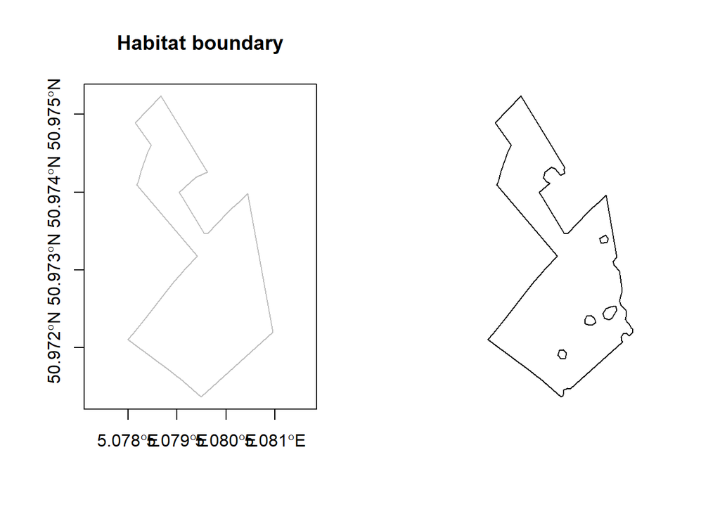

```r
par(mfrow=c(1,2))
plot(st_geometry(AOI_wgs84),border='grey',axes=T,main="Habitat boundary")
for (i in 1:nrow(trees_object)){
   AOI_wgs84 <- st_difference(AOI_wgs84,trees_object[i,])
}
plot(st_geometry(AOI_wgs84,border='grey',axes=T,main="Habitat boundary without trees"))
```

```r
par(mfrow=c(1,1))
```

See how inundation changes in in the past (based on winter ortho images) for your area. Select the year the want to visualize.

```r
# Website with the public wms files for Flanders: https://wms.michelstuyts.be/?lang=nl
layer2024 <- "OMWRGB24VL"# select the winter image of 2024
layer2023 <- "OMWRGB23VL" # select the winter image of 2023
layer2022 <- "OMWRGB22VL"# select the winter image of 2022
layer2021 <- "OMWRGB21VL"# select the winter image of 2021
layer2020 <- "OMWRGB20VL"# select the winter image of 2020

map <- leaflet() %>%
  addWMSTiles(
    wms_ortho,
    layers = layer2020,
    options = WMSTileOptions(format = "image/png", transparent = FALSE),
    group = "OMWRGB20VL"
  ) %>%
  addWMSTiles(
    wms_ortho,
    layers = layer2021,
    options = WMSTileOptions(format = "image/png", transparent = FALSE),
    group = "OMWRGB21VL"
  ) %>%
  addWMSTiles(
    wms_ortho,
    layers = layer2022,
    options = WMSTileOptions(format = "image/png", transparent = FALSE),
    group = "OMWRGB22VL"
  ) %>%
  addWMSTiles(
    wms_ortho,
    layers = layer2023,
    options = WMSTileOptions(format = "image/png", transparent = FALSE),
    group = "OMWRGB23VL"
  ) %>%
  addWMSTiles(
    wms_ortho,
    layers = layer2024,
    options = WMSTileOptions(format = "image/png", transparent = FALSE),
    group = "OMWRGB24VL"
  ) %>%
  fitBounds(
    lng1 = bb[["xmin"]],
    lat1 = bb[["ymin"]],
    lng2 = bb[["xmax"]],
    lat2 = bb[["ymax"]]
  )  %>%
  addPolygons(data = AOI_wgs84, color = "red", weight = 2) %>%
  addMarkers(
    data = points_wgs84,
    lng = st_coordinates(points_wgs84)[,1],
    lat = st_coordinates(points_wgs84)[,2],
    popup = points_wgs84$label
  ) %>%
  addLayersControl(
    baseGroups = c("OMWRGB20VL","OMWRGB21VL","OMWRGB22VL","OMWRGB23VL","OMWRGB24V"),
    options = layersControlOptions(collapsed = FALSE)
  )

map
```

[interactive chart not shown]

Most recent:

Date winter images study area:

- most recent: 5/03/2025
- 2024: 06/04/2024
- 2023: 01/03/2023
- 2022: 04/03/2022
- 2021: 01/03/2021
- 2020: 24/03/2020